# Joint-Survey Area Departure from Modern Conditions

What time horizons to SSP scenarios cross critical temperature thresholds?

Author

Adam Kemberling

Published

November 8, 2023

# About

For communication around climate change impacts sometimes it is helpful to look at when temperatures are expected to cross critical thresholds. As an example: When temperatures are at 1C above current/recent conditions, this is the behavior we anticipate for our study species.

Another use case is for highlighting the differences between climate ensemble scenarios. Scenario X may have us crossing 2C as soon as 2060, where scenario Y has us limiting warming below 2C for the remainder of the decade. Using these milestones is a tool for communicating the different outcomes associated with or choices.

Because our fishing community research and our cross-survey study area is so long, we have approached these milestones from the perspective of the entire survey area.

### Joint Survey Area

In this document we use the following area for expectation setting with these two SSP scenarios.

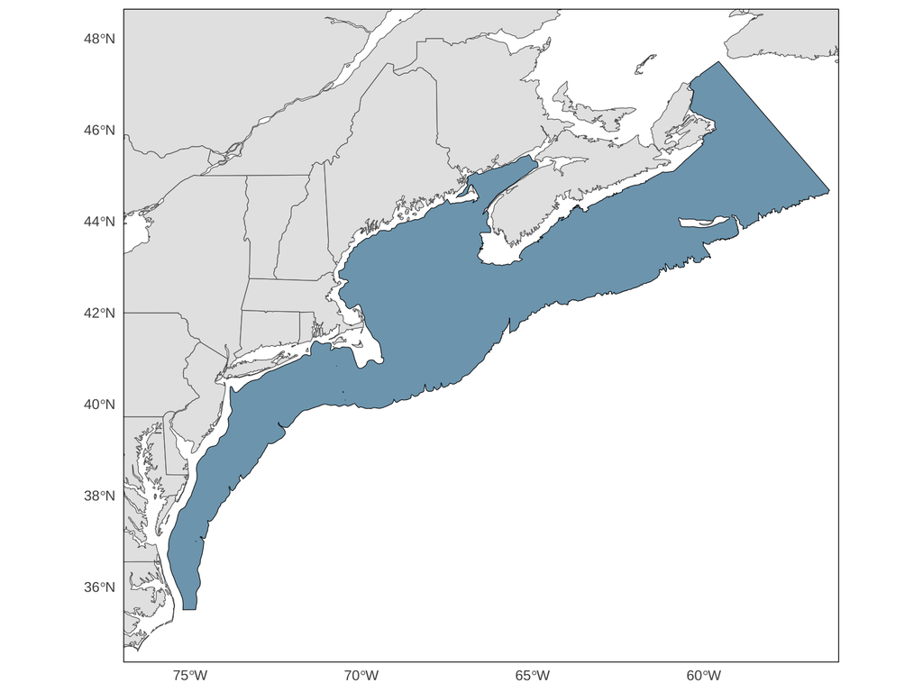

# Changes in Time

The following figure displays how SSP5 compares to observed data, and its predicted future trends.

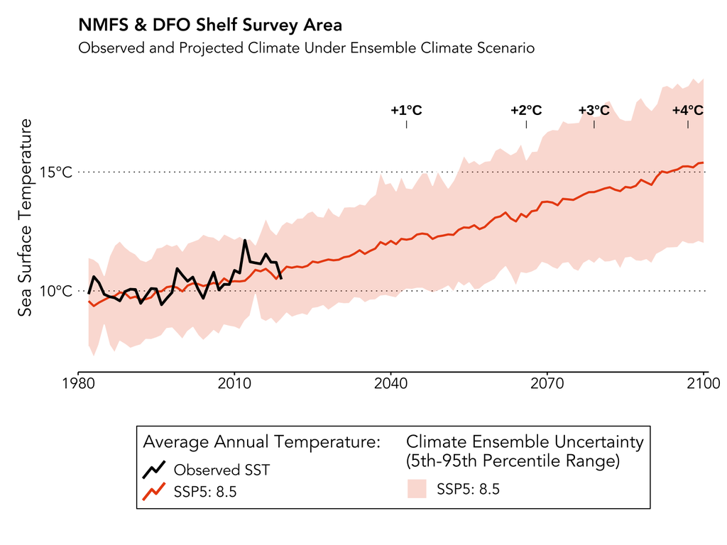

**Sea Surface Temperature**

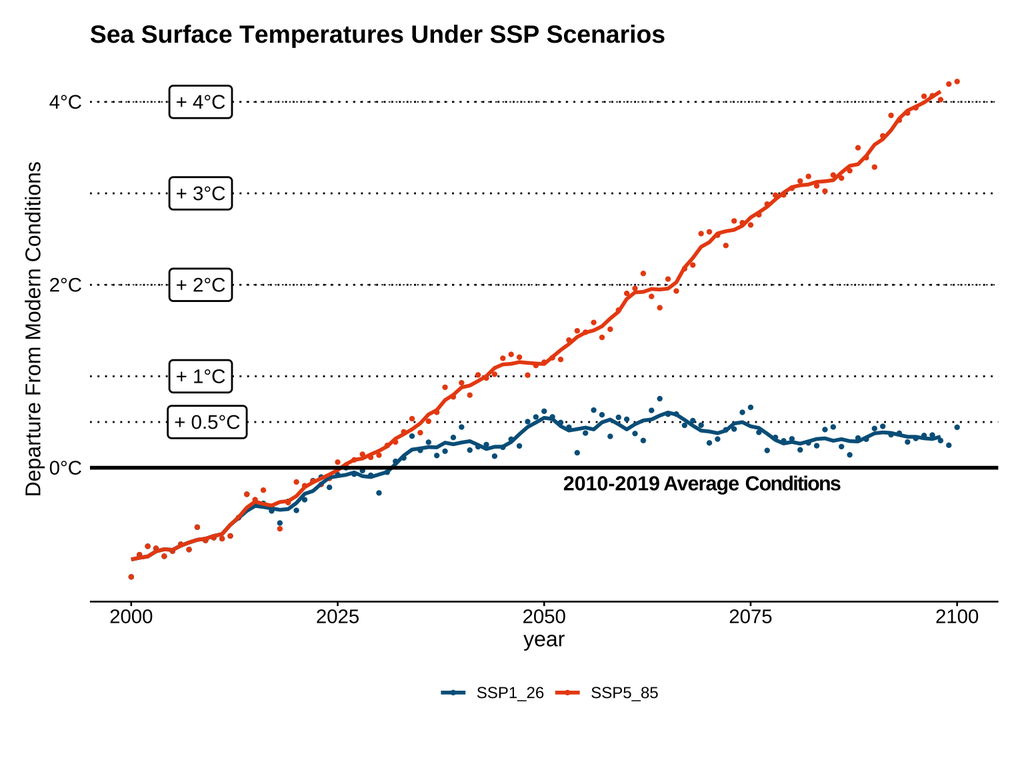

**Sea Floor Temperature**

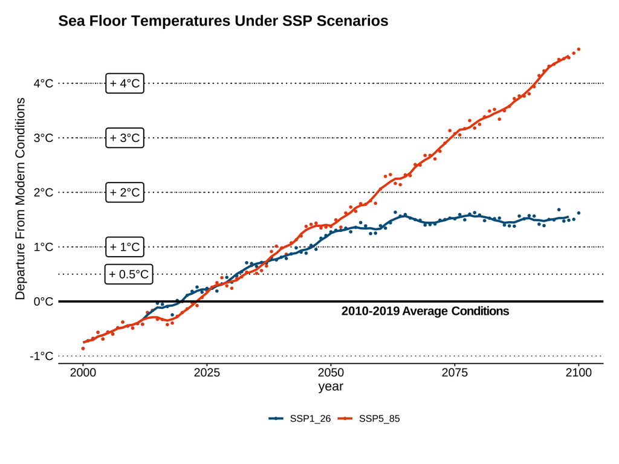

# Contrasting Two SSP Scenarios

**Sea Surface Temperature**

SSP1: 2.6

Sea Surface Temperatures +0.5°C Above 2010-2019 Averages

Climate ensemble mean estimates exceed + 0.5 °C in **2050**

As soon as (95th Percentile): **1953**

As late as (5th Percentile): **Never**

SSP5: 8.5

Sea Surface Temperatures +0.5°C Above 2010-2019 Averages

Climate ensemble mean estimates exceed + 0.5 °C in **2036**

As soon as (95th Percentile): **1953**

As late as (5th Percentile): **2093**

**Sea Floor Temperature**

SSP1: 2.6

Sea Floor Temperatures +0.5°C Above 2010-2019 Averages

Climate ensemble mean estimates exceed + 0.5 °C in **2031**

As soon as (95th Percentile): **1959**

As late as (5th Percentile): **Never**

SSP5: 8.5

Sea Floor Temperatures +0.5°C Above 2010-2019 Averages

Climate ensemble mean estimates exceed + 0.5 °C in **2033**

As soon as (95th Percentile): **1959**

As late as (5th Percentile): **2084**

# Important Junctions for SSP5 8.5

Of these two SSP scenario ensembles, SSP5 8.5 is the only one that continues to exceed increasing temperature milestones. The below table shows the year in which mean temperatures from each of the ensembles crossing temperature milestones above the average conditions of the last decade.

Oceanic Condition Crossing Points Under SSP Scenario Ensembles

Thresholds set against ten-year (2010-2019) average annual conditions for joint NMFS & DFO survey area

| Temperature Threshold °C | Sea Surface Temperatures | Sea Floor Temperatures |
| --- | --- | --- |
| SSP1: 2.6 |  |  |
| 0.5 | 2050 | 2031 |
| 1.0 | - | 2047 |
| 1.5 | - | 2063 |
| 2.0 | - | - |
| 3.0 | - | - |
| 4.0 | - | - |
| SSP5: 8.5 |  |  |
| 0.5 | 2036 | 2033 |
| 1.0 | 2043 | 2041 |
| 1.5 | 2056 | 2052 |
| 2.0 | 2066 | 2060 |
| 3.0 | 2079 | 2075 |
| 4.0 | 2097 | 2092 |

A work by [Adam A. Kemberling](https://github.com/adamkemberling/)

*Akemberling@gmri.org*